# Predictive Modeling

## The Learning Problem

If you show a picture to a three-year-old and ask if there is a tree in it, you will likely get the correct answer. If you ask a thirty-year-old what the deﬁnition of a tree is, you will likely get an inconclusive answer. We didn't learn what a tree is by studying the mathematical deﬁnition of trees. We learned it by looking at trees.

In other words, we learned from data. Learning from data is used in situations where we don't have an analytic solution, but we do have data that we can use to construct an empirical solution.

Suppose that a bank receives thousands of credit card applications every day, and it wants to automate the process of evaluating them.

Each customer record has personal information related to credit , such as annual salary, years in residence, outstanding loans, etc. The record also keeps track of whether approving credit for that customer was a good idea, i.e . , did the bank make money on that customer. This data guides the construction of a successful formula for credit approval that can be used on future applicants.

## Components of Learning

[figure not shown]

## A Simple Learning Model

Given a speciﬁc learning problem, the target function and training examples are dictated by the problem. However, the learning algorithm and hypothesis set are not. These are solution tools that we get to choose. The hypothesis set and learning algorithm are referred to informally as the learning model.

Let $\mathcal{X}=\mathbb{R}^d$ be the input space, and let $\mathcal{Y}=\{+1, -1\}$.

What is the meaning of $\mathcal{X}$ and $\mathcal{Y}$ in the credit approval problem?

The functional form $h(\boldsymbol{x}) \in \mathcal{H}$ that we choose here gives diﬀerent weights to the diﬀerent coordinates of $\boldsymbol{x}$, reﬂecting their relative importance in the credit decision. The weighted coordinates are then combined to form a *credit score* and the result is compared to a threshold value.

- Approve credit if $\sum_{i=1}^d w_i x_i >$ threshold
- Deny credit if $\sum_{i=1}^d w_i x_i <$ threshold

### The Perceptron

This formula can be written more compactly as

$$ h(\boldsymbol{x}) = sign\left(\left(\sum_{i=1}^d w_i x_i \right) + b \right) = sign(\boldsymbol{w}^T \boldsymbol{x}) $$

This model of $\mathcal{H}$ is called the perceptron, a name that it got in the context of artificial intelligence. The optimal choices of weights and bias deﬁne the ﬁnal hypothesis $g \in \mathcal{H}$ that the algorithm produces.

- What is the meaning of some negative weights?
- What is the meaning of a large bias $b$ term?
- What kind of space is generated by the perceptron?

### The Perceptron Learning Algorithm (PLA)

The perceptron learning algorithm (PLA), will determine what $\boldsymbol{w}$ should be, based on the data. Let us assume that the data set is linearly separable, which means that there is a vector $\boldsymbol{w}$ that makes $h(\boldsymbol{x})$ achieve the correct decision $y_n$ on all the training examples.

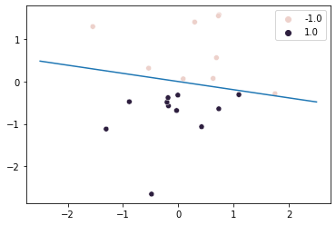

```python
ax.figure
```

#### Algorithm

While there exists missclassifed points in the dataset $\mathcal{D}$

1. Initialize $\boldsymbol{w}(0)$ randomly
2. Compute $h(\boldsymbol{x})$ for each $\boldsymbol{x}$ in the dataset $\mathcal{D}$.
3. Pick a missclassiﬁed example from $(\boldsymbol{x}_1, y_1 ), \cdots, (\boldsymbol{x}_N, y_N)$, call it $(\boldsymbol{x}(t), y(t))$.
4. Since the example is misclassiﬁed, we have $y(t) \neq sign(\boldsymbol{w}^T(t) \boldsymbol{x}(t))$, then, update using

$$ \boldsymbol{w}(t+1) = \boldsymbol{w}(t) + y(t) \boldsymbol{x}(t) $$

#### Excercise

The previous weight update rule has the nice interpretation that it moves in the direction of classifying $\boldsymbol{x}(t)$ correctly.

1. Show that $y(t) \boldsymbol{w}^T(t) \boldsymbol{x}(t) < 0$ [Hint: $\boldsymbol{x}(t)$ in missclassified by $\boldsymbol{w}(t)$].
2. Show that $y(t) \boldsymbol{w}^T(t+1) \boldsymbol{x}(t) > y(t) \boldsymbol{w}^T(t) \boldsymbol{x}(t)$ [Hint: use $\boldsymbol{w}(t+1) = \boldsymbol{w}(t) + y(t) \boldsymbol{x}(t)$].
3. As far as classifying $\boldsymbol{x}(t)$ is concerned, argue that the move from $\boldsymbol{w}(t)$ to $\boldsymbol{w}(t + 1)$ is a move "in the right direction".

## Learning Versus Design

- Learning is based on data.
- Design is based on speciﬁcations.

Consider the problem of recognizing coins of diﬀerent denominations

- In the learning approach, we are given a sample of coins from each of the four denominations and we use these coins as our data set.
- In the design approach, we call the appropiate institution and ask them about the speciﬁcations of diﬀerent coins.

Is a machine learning-based solution the best solution?

## Types of Learning

- Supervised learning: Learn from data.
- Reinforcement learning: Learn from experience.
- Unsupervised learning: Learn from patterns (structures).

[figure not shown]

## Is Learning Feasible?

What is the value of $f$?

[figure not shown]

### Outside The Data Set

Does the data set $\mathcal{D}$ tell us anything outside of $\mathcal{D}$ that we didn't know before?

- Yes!: then we have learned something.
- No: We can conclude that learning is not feasible.

Since we maintain that $f$ is an unknown function, we can prove that $f$ remains unknown outside of $\mathcal{D}$.

Consider the boolean target function $f(\boldsymbol{x}_n)$ described below. The final hypothesis $g$ is chosen based on the five examples in $\mathcal{D}$. If we remain true to the notion of unknown target, we cannot exclude any $f_1, \cdots, f_8$ from being the true $f$.

| $$\boldsymbol{x}_n$$ | $$f(\boldsymbol{x}_n)$$ | $$g$$ | $$f_1$$ | $$f_2$$ | $$f_3$$ | $$f_4$$ | $$f_5$$ | $$f_6$$ | $$f_7$$ | $$f_8$$ |
| --- | --- | --- | --- | --- | --- | --- | --- | --- | --- | --- |
| 0 0 0 | ○ | ○ | ○ | ○ | ○ | ○ | ○ | ○ | ○ | ○ |
| 0 0 1 | ● | ● | ● | ● | ● | ● | ● | ● | ● | ● |
| 0 1 0 | ● | ● | ● | ● | ● | ● | ● | ● | ● | ● |
| 0 1 1 | ○ | ○ | ○ | ○ | ○ | ○ | ○ | ○ | ○ | ○ |
| 1 0 0 | ● | ● | ● | ● | ● | ● | ● | ● | ● | ● |
| 1 0 1 |  | ? | ○ | ○ | ○ | ○ | ● | ● | ● | ● |
| 1 1 0 |  | ? | ○ | ○ | ● | ● | ○ | ○ | ● | ● |
| 1 1 1 |  | ? | ○ | ● | ○ | ● | ○ | ● | ○ | ● |

Which is the true $f$? $f_1, f_2, \cdots$ or $f_8$?

It doesn't matter what the algorithm does or what hypothesis set $\mathcal{H}$ is used. Whether $\mathcal{H}$ has a hypothesis that perfectly agrees with $\mathcal{D}$ or not, and whether the learning algorithm picks that hypothesis or picks another one that disagrees with $\mathcal{D}$, it makes no difference whatsoever as far as the performance outside of $\mathcal{D}$ is concerned.

**The performance outside $\mathcal{D}$ is all that matters in learning!**

### Probability to the Rescue

We will show that we can indeed infer something outside $\mathcal{D}$ using only $\mathcal{D}$, but in a probabilistic way. Let's take the simplest case of picking a sample, and see when we can say something about the objects outside the sample.

[figure not shown]

What does the value of $v$ tell us about the value of $\mu$ ?

Can we can get mostly green marbles in the sample while the bin has mostly red marbles?

To quantify the relationship between $v$ and $\mu$, we use a simple bound called the Hoeﬀding Inequality. It states that for any sample size $N$

$$ P[|v-\mu|>\epsilon] \leq 2e^{-2\epsilon^2N} $$

But how does the bin model relate to the learning problem?

Remember the next because it is very important but sometimes forgotten, **only under these assumptions, the next result will work!**

If the inputs $\boldsymbol{x}_i, \cdots, \boldsymbol{x}_N$ in $\mathcal{D}$ are **picked independently** according to some distribution $P$ on $\mathcal{X}$, we will get a random sample of:

- Red marbles $$h(\boldsymbol{x}_n) \neq f(\boldsymbol{x}_n)$$
- Green marbles $$h(\boldsymbol{x}_n) = f(\boldsymbol{x}_n) $$

With this equivalence, the Hoeffding inequality can be applied to the learning problem.

- What is the role of the sample?
- What is the role of the bin?

Consider the in-sample error

$$ E_{in}(h) = \frac{1}{N} \sum_{n=1}^N [\![ h(\boldsymbol{x}_n) \neq f(\boldsymbol{x}_n) ]\!] $$

and the out-of-sample error,

$$ E_{out}(h) = P[ h(\boldsymbol{x}_n) \neq f(\boldsymbol{x}_n) ] $$

appling the Hoeﬀding bound in one hypotesis

$$ P[|v-\mu| > \epsilon] = P[|E_{in}-E_{out}| > \epsilon] \leq 2e^{-2 \epsilon^2 N} $$

Why is this previous result important?

Unfortunately, we have no control over $E_{in}$ in our current situation, since it is based on a particular hypothesis $h$. In real learning, we explore an entire hypothesis set $\mathcal{H}$, looking for some $h \in \mathcal{H}$ that has a small error rate.

Let us consider an entire hypothesis set $\mathcal{H}$ instead of just one hypothesis $h$, and assume for the moment that $\mathcal{H}$ has a ﬁnite number of hypotheses

$$ \mathcal{H} = \{ h_1, \cdots, h_M \} $$

With multiple hypotheses in $\mathcal{H}$, the learning algorithm picks the final hypothesis $g$ based on $\mathcal{D}$. Since $g$ has to be in $\mathcal{H}$, then:

$$ P(|E_{in}(g) - E_{out}(g)| > \epsilon) \\ \leq P[ |E_{in}(h_1) - E_{out}(h_1)| > \epsilon \textbf{ or }|E_{in}(h_2) - E_{out}(h_2)| > \epsilon \cdots \textbf{ or }|E_{in}(h_M) - E_{out}(h_M)| > \epsilon ] \\ \leq 2 M e^{-2 \epsilon^2 N} $$

What additional terms introduce this inequality? What they mean?

## Error and Noise

Now, we are revisiting two notions in the learning problem in order to bring them closer to the real world. The first notion is what approximation means when we say that our hypothesis approximates the target function well. The second notion is about the nature of the target function. In many situations, there is noise that makes the output of $f$ not uniquely determined by the input.

### Error Measures

An error measure quantifies how well each hypothesis $h$ in the model approximates the target function $f$,

$$ Error=E(h, f) $$

While $E(h, f)$ is based on the entirety of $h$ and $f$, it is almost universally defined based on the errors on individual input points $\boldsymbol{x}$. If we define a pointwise error measure $e(h(\boldsymbol{x}), f(\boldsymbol{x}))$, the overall error will be the average value of this pointwise error.

In an ideal world, $E(h, f)$ should be user-specified and it depends on how the system is going to be used, rather than on any inherent criterion.

### Noisy Targets

In many practical applications, the data we learn from are not generated by a deterministic target function $f$. Instead, they are generated in a noisy way such that the output is not uniquely determined by the input.

This situation can be readily modeled within the same framework that we have. Instead of $y=f(\boldsymbol{x})$, we have a target distribution $P(y|\boldsymbol{x})$

## The General Supervised Learning Problem

[figure not shown]